# Logistic regression

## Task 2

### Reading the data, printing the names of the variables in the data and exploring the structure and dimensions of the data

```r
data <- read.csv(file = "StudentData.csv")
colnames(data)
```

```
##  [1] "school"     "sex"        "age"        "address"    "famsize"
##  [6] "Pstatus"    "Medu"       "Fedu"       "Mjob"       "Fjob"
## [11] "reason"     "nursery"    "internet"   "traveltime" "studytime"
## [16] "failures"   "famrel"     "freetime"   "goout"      "Dalc"
## [21] "Walc"       "health"     "absences"   "G1"         "G2"
## [26] "G3"         "alc_use"    "high_use"   "guardian"   "schoolsup"
## [31] "famsup"     "paid"       "activities" "higher"     "romantic"
```

```r
summary(data)
```

```
##  school   sex          age        address famsize   Pstatus
##  GP:342   F:198   Min.   :15.00   R: 81   GT3:278   A: 38
##  MS: 40   M:184   1st Qu.:16.00   U:301   LE3:104   T:344
##                   Median :17.00
##                   Mean   :16.59
##                   3rd Qu.:17.00
##                   Max.   :22.00
##       Medu            Fedu             Mjob           Fjob
##  Min.   :0.000   Min.   :0.000   at_home : 53   at_home : 16
##  1st Qu.:2.000   1st Qu.:2.000   health  : 33   health  : 17
##  Median :3.000   Median :3.000   other   :138   other   :211
##  Mean   :2.806   Mean   :2.565   services: 96   services:107
##  3rd Qu.:4.000   3rd Qu.:4.000   teacher : 62   teacher : 31
##  Max.   :4.000   Max.   :4.000
##         reason    nursery   internet    traveltime      studytime
##  course    :140   no : 72   no : 58   Min.   :1.000   Min.   :1.000
##  home      :110   yes:310   yes:324   1st Qu.:1.000   1st Qu.:1.000
##  other     : 34                       Median :1.000   Median :2.000
##  reputation: 98                       Mean   :1.448   Mean   :2.037
##                                       3rd Qu.:2.000   3rd Qu.:2.000
##                                       Max.   :4.000   Max.   :4.000
##     failures          famrel         freetime        goout
##  Min.   :0.0000   Min.   :1.000   Min.   :1.00   Min.   :1.000
##  1st Qu.:0.0000   1st Qu.:4.000   1st Qu.:3.00   1st Qu.:2.000
##  Median :0.0000   Median :4.000   Median :3.00   Median :3.000
##  Mean   :0.2016   Mean   :3.937   Mean   :3.22   Mean   :3.113
##  3rd Qu.:0.0000   3rd Qu.:5.000   3rd Qu.:4.00   3rd Qu.:4.000
##  Max.   :3.0000   Max.   :5.000   Max.   :5.00   Max.   :5.000
##       Dalc            Walc           health         absences
##  Min.   :1.000   Min.   :1.000   Min.   :1.000   Min.   : 0.0
##  1st Qu.:1.000   1st Qu.:1.000   1st Qu.:3.000   1st Qu.: 1.0
##  Median :1.000   Median :2.000   Median :4.000   Median : 3.0
##  Mean   :1.482   Mean   :2.296   Mean   :3.573   Mean   : 4.5
##  3rd Qu.:2.000   3rd Qu.:3.000   3rd Qu.:5.000   3rd Qu.: 6.0
##  Max.   :5.000   Max.   :5.000   Max.   :5.000   Max.   :45.0
##        G1              G2              G3           alc_use
##  Min.   : 2.00   Min.   : 4.00   Min.   : 0.00   Min.   :1.000
##  1st Qu.:10.00   1st Qu.:10.00   1st Qu.:10.00   1st Qu.:1.000
##  Median :12.00   Median :12.00   Median :12.00   Median :1.500
##  Mean   :11.49   Mean   :11.47   Mean   :11.46   Mean   :1.889
##  3rd Qu.:14.00   3rd Qu.:14.00   3rd Qu.:14.00   3rd Qu.:2.500
##  Max.   :18.00   Max.   :18.00   Max.   :18.00   Max.   :5.000
##   high_use         guardian   schoolsup famsup     paid     activities
##  Mode :logical   father: 91   no :331   no :144   no :205   no :181
##  FALSE:268       mother:275   yes: 51   yes:238   yes:177   yes:201
##  TRUE :114       other : 16
##
##
##
##  higher    romantic
##  no : 18   no :261
##  yes:364   yes:121
##
##
##
##
```

```r
str(data)
```

```
## 'data.frame':    382 obs. of  35 variables:
##  $ school    : Factor w/ 2 levels "GP","MS": 1 1 1 1 1 1 1 1 1 1 ...
##  $ sex       : Factor w/ 2 levels "F","M": 1 1 1 1 1 2 2 1 2 2 ...
##  $ age       : int  18 17 15 15 16 16 16 17 15 15 ...
##  $ address   : Factor w/ 2 levels "R","U": 2 2 2 2 2 2 2 2 2 2 ...
##  $ famsize   : Factor w/ 2 levels "GT3","LE3": 1 1 2 1 1 2 2 1 2 1 ...
##  $ Pstatus   : Factor w/ 2 levels "A","T": 1 2 2 2 2 2 2 1 1 2 ...
##  $ Medu      : int  4 1 1 4 3 4 2 4 3 3 ...
##  $ Fedu      : int  4 1 1 2 3 3 2 4 2 4 ...
##  $ Mjob      : Factor w/ 5 levels "at_home","health",..: 1 1 1 2 3 4 3 3 4 3 ...
##  $ Fjob      : Factor w/ 5 levels "at_home","health",..: 5 3 3 4 3 3 3 5 3 3 ...
##  $ reason    : Factor w/ 4 levels "course","home",..: 1 1 3 2 2 4 2 2 2 2 ...
##  $ nursery   : Factor w/ 2 levels "no","yes": 2 1 2 2 2 2 2 2 2 2 ...
##  $ internet  : Factor w/ 2 levels "no","yes": 1 2 2 2 1 2 2 1 2 2 ...
##  $ traveltime: int  2 1 1 1 1 1 1 2 1 1 ...
```

[output cut: 21 more lines]

```r
dim(data)
```

```
## [1] 382  35
```

> There are 382 observations and 35 variables in our dataset. The data showing achievements of students in secondary education of two Portuguese schools.We are using two datasets and trying to observe the performance of the students in mathematics and portuguese language with regard to consumption of alcohol and other social and school related features.

## Task 3

### 4 variables in the dataset and my hypothesis about their relationships with alcohol consumption

- failures: This numeric variable shows us how many classes each student failed in the past. My hypothesis is that with high alcohol consumption, the student will fail more classes that wit low alcohol consumption. On the other hand, variable which shows us how much alcohol student consume might increase when student pass the class (perhaps because he is celebrating successful exam) . This would imply that the alcohol consumption is actually higher when the number of failed classes is low. However, I still think that this will not be the case and that consumption of alcohol and number of failed classes are positively correlated.
- health: The higher the consumption of alcohol, the worse the health of a student will be.
- absences: This variable will be also positively correlated with consumption of alcohol, since students might be drinking instead of attending school. They may also have a hangover after a drinking evening and therefore not go to school.
- G3 (final grade): Final grand probably tend to be lower with higher consumption oc alcohol. However, similar thing as in the case oc variable “failures” may apply here. Students may be drinking after they receive a nice final grade.

## Task 4

### Distributions of chosen variables

```r
library(tidyr)
library(dplyr)
```

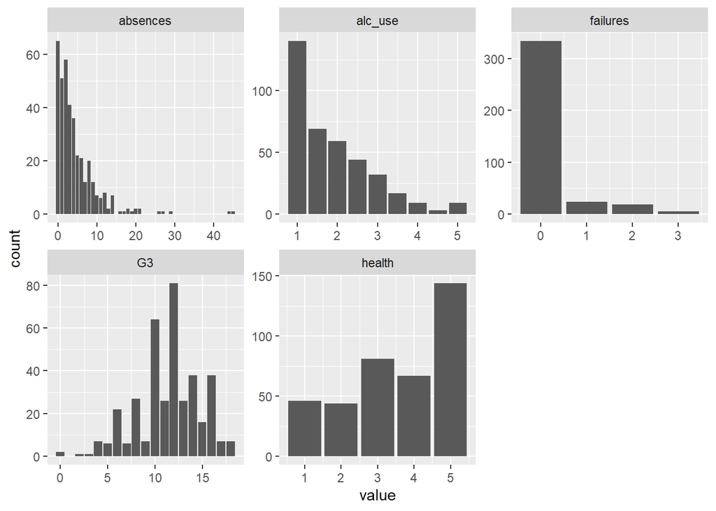

```r
library(ggplot2)
selected_variables <- select(data, one_of(c("failures", "health", "absences", "G3", "alc_use")))
gather(selected_variables) %>% ggplot(aes(value)) + facet_wrap("key", scales = "free") + geom_bar()
```

> From the graps we can clearly see the distributions of the variables. In case of variable “alc_use”, value 1 corresponds to very low consumption and value 5 to very high consumption. In case of variable “health, value 1 corresponds to very bad current health status and value 5 to very good current health status. Value 0 in variable”failures" means no failure at all.

### Exploring relationships between chosen variables and alcohol consumption

```r
library(GGally)
```

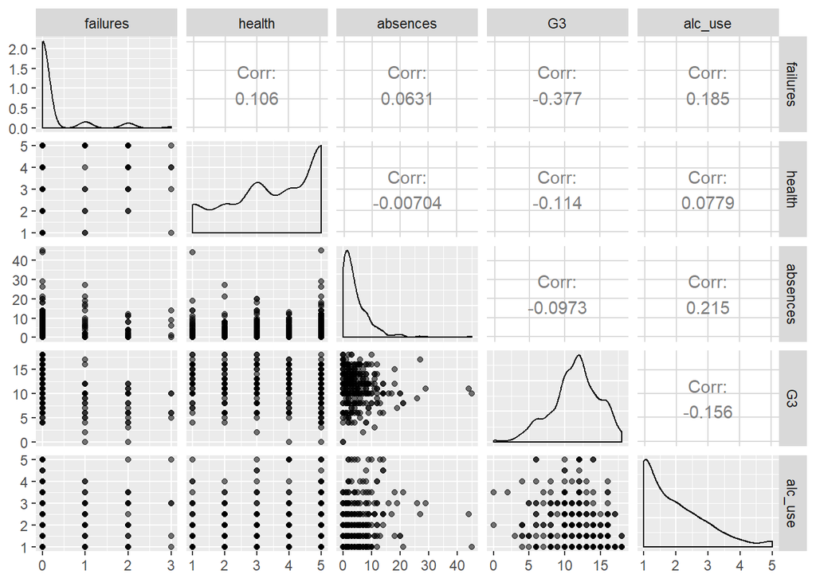

```r
library(ggplot2)

# Creating a plot matrix
selected_variables <- select(data, one_of(c("failures", "health", "absences", "G3", "alc_use")))
p <- ggpairs(selected_variables, mapping = aes(alpha=0.3), lower = list(combo = wrap("facethist", bins = 20)))
p
```

> From this graph we can see again distribution of each variable and also some other interesting things. We can see how variables are correlated to each other. From our chosen variables, the variable “absences” is the one which is influenced the most by the consumption of alcohol , since they have the highest value of correlation coefficient (0.215). Final grade (G3) is the only variable which is in negative relationship with the alcohol consumption. Those results are quite similar to my predictions, although one different and kind of interesting result is that health and alcohol consumption are positively correlated (although the correlation coefficient is very low).

## Task 5

### Applying logistic regression

```r
m <- glm(high_use ~ failures + health + absences + G3, data = data, family = "binomial")
summary(m)
```

```
##
## Call:
## glm(formula = high_use ~ failures + health + absences + G3, family = "binomial",
##     data = data)
##
## Deviance Residuals:
##     Min       1Q   Median       3Q      Max
## -2.3178  -0.7943  -0.7015   1.1814   1.9006
##
## Coefficients:
##             Estimate Std. Error z value Pr(>|z|)
## (Intercept) -1.13164    0.58665  -1.929 0.053731 .
## failures     0.39341    0.19912   1.976 0.048184 *
## health       0.07387    0.08602   0.859 0.390474
## absences     0.08458    0.02283   3.705 0.000212 ***
## G3          -0.04286    0.03791  -1.131 0.258225
## ---
## Signif. codes:  0 '***' 0.001 '**' 0.01 '*' 0.05 '.' 0.1 ' ' 1
##
## (Dispersion parameter for binomial family taken to be 1)
##
##     Null deviance: 465.68  on 381  degrees of freedom
## Residual deviance: 437.96  on 377  degrees of freedom
## AIC: 447.96
##
## Number of Fisher Scoring iterations: 4
```

> From the summary of the fitted model we can see that variales failures and absences are statistically significant. Variable failures is significant at 95% significance level, meanwhile variable absences at 99% with very low p-value. Other variables are statistically insignificant.

### Computing odds ratios and confidence intervals

```r
OR <- coef(m) %>% exp
CI <- confint(m) %>% exp
cbind(OR, CI)
```

```
##                    OR     2.5 %   97.5 %
## (Intercept) 0.3225027 0.1000825 1.004240
## failures    1.4820265 1.0036151 2.204355
## health      1.0766655 0.9109340 1.277264
## absences    1.0882646 1.0428902 1.140667
## G3          0.9580477 0.8892855 1.032188
```

## Task 6

### Exploring the predictive power of our model

```r
m2 <- glm(high_use ~ failures + absences + G3, data = data, family = "binomial")
probabilities <- predict(m2, type = "response")
data <- mutate(data, probability = probabilities)
data <- mutate(data, prediction = probability > 0.5)
table(high_use = data$high_use, prediction = data$prediction)
```

```
##         prediction
## high_use FALSE TRUE
##    FALSE   258   10
##    TRUE     98   16
```

> From the total of 382 students, our model correctly predicted 274 of them and 108 incorrectly.

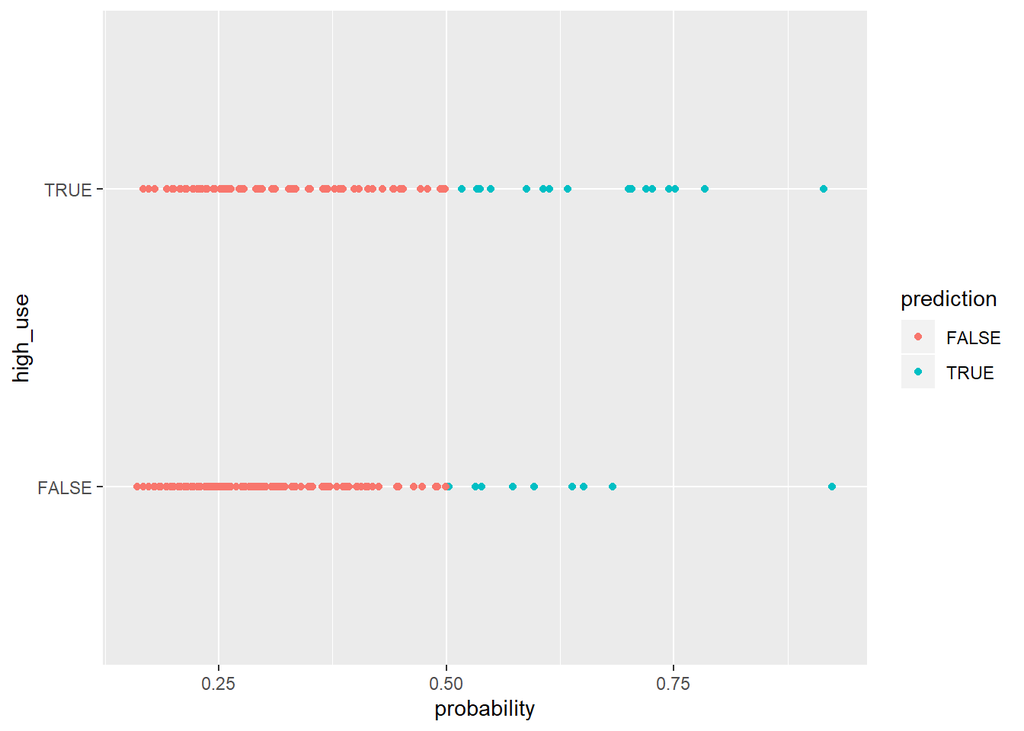

```r
g <- ggplot(data, aes(x = probability, y = high_use, col = prediction))
g + geom_point()
```